# First_Forecast_Project

Bibek Kandel

2024-02-28

2024-02-29

```r
install.packages('tidymodels')
install.packages('readr') # package for applying simple forecasting methods
install.packages('lubridate') # package for dealing with time series data sets and tsibble objects
install.packages('tidyverse') # collection of R packages for data manipulation, analysis, and visualisation
install.packages('dplyr')# working with dates and times
install.packages('ranger')
install.packages('randomForest')
remotes::install_github('eco4cast/neon4cast') # package from NEON4cast challenge organisers to assist with forecast building and submission
```

#Initialize the libraries

```r
library(tidymodels)
```

[output not shown]

```
## • Use tidymodels_prefer() to resolve common conflicts.
```

```r
library(readr)
library(lubridate)
library(dplyr)
library(ranger)
library(randomForest)
```

[output not shown]

[output cut: 292 more lines]

[output not shown]

[figure not shown]

[figure not shown]

[figure not shown]

[figure not shown]

[figure not shown]

[figure not shown]

[figure not shown]

[figure not shown]

```r
#Update the workflow with the best hyper-parameters
final_workflow <-
  wflow %>%
  finalize_workflow(best_hyperparameters)


# Fit to all training data
fit <- final_workflow |>
  fit(data = train_data)

fit
```

[output not shown]

#Step 5: Predict Test Data

```r
#Now we will predict the testing data using the model that was fit to the training data.
test_data <- test_data |>
  na.omit()
predictions <- predict(fit, new_data = test_data)

predictions #single column with predictions
```

[output not shown]

```r
#We need to combine the .pred column with the testing data using the bind_cols function
pred_test <- bind_cols(test_data, predictions)
pred_test
```

```
## # A tibble: 955 × 10
##    datetime   site_id temperature air_temperature eastward_wind northward_wind
##    <date>     <chr>         <dbl>           <dbl>         <dbl>          <dbl>
##  1 2021-01-05 BARC           16.7           12.3        -0.688           2.12
##  2 2021-01-07 BARC           16.1           14.2         0.0914         -1.54
##  3 2021-01-12 BARC           15.4           15.9         0.358           1.30
##  4 2021-01-15 BARC           14.9           12.6         2.40            1.10
##  5 2021-01-16 BARC           14.8           10.9        -0.0152          3.08
##  6 2021-01-22 BARC           15.2           16.9         1.04            2.04
##  7 2021-01-25 BARC           16.3           19.6         1.51           -0.438
##  8 2021-01-28 BARC           17.6           14.6        -2.20            1.74
##  9 2021-01-29 BARC           16.5            9.78       -1.41            0.151
## 10 2021-02-02 BARC           15.4            6.83       -2.12            4.07
## # ℹ 945 more rows
## # ℹ 4 more variables: surface_downwelling_shortwave_flux_in_air <dbl>,
## #   windspeed <dbl>, doy <dbl>, .pred <dbl>
```

#Step 6: Evaluate model

```r
#We will evaluate the performance of our predictions of the testing data using two metrics (rmse and rsq). The function metric_set defines the set of metric we will be using them. It creates a function called multi_metric() that we will use to calculate the metrics. We pipe in the predicted test data (pred_test) and tell the function that our truth (i.e., observed data) is the temperature column and the predictions (i.e., estimate) is the .pred column
multi_metric <- metric_set(rmse, rsq)

metric_table <- pred_test |>
  multi_metric(truth = temperature, estimate = .pred)

metric_table
```

[output not shown]

```r
predictions <- pred_test$.pred
actual_values <- pred_test$temperature

ggplot(data = data.frame(predictions, actual_values),
       aes(x=predictions, y=actual_values))+
  geom_point()+
  geom_abline(intercept=0, slope=1, linetype="dashed", color = "red")+
  labs(title = "Scatter plot of predictions and observations",
  x = "Predictions",
  y = "Actual values") +
  theme_minimal()
```

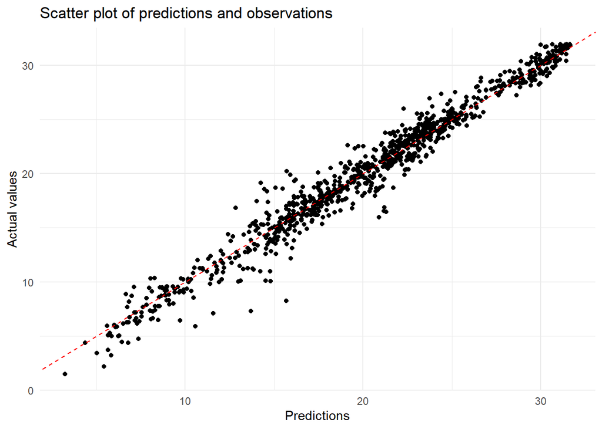

[figure not shown]

#Step 7: Deploy model

```r
#same as deterministic forecast
targets_future <- noaa_future_daily |>
  dplyr::mutate(temperature = NA,
         doy = yday(datetime)) |>
  filter(parameter == 1) |>
  select(-parameter)

#You will notice that the temperature is all NA because you don’t know what the temperature is of the site.

targets_future
```

[output not shown]

```r
#As in “Step 5: Predict Test Data”, use the model fitting on the training data (fit) to predict the new data.
new_predictions <- predict(fit, new_data = targets_future)

#Probabilistic forecast
#residual for each ensemble prediction
residuals <- pred_test$.pred - pred_test$temperature
err <- mean(residuals, na.rm = TRUE)

#Create sigma distribution to use for process uncertainty later
sigma <- sd(residuals, na.rm = TRUE)

targets_future <- noaa_future_daily |>
  mutate(temperature = NA,
         doy = yday(datetime))

tidymodels_forecast <- data.frame()

for(i in unique(targets_future$parameter)){
  curr_ens <- targets_future |>
    filter(parameter == i) |>
    select(-parameter)

  new_predictions <- predict(fit, new_data = curr_ens)

  #add process uncertainty to each ensemble members
  new_predictions$.pred = new_predictions$.pred + rnorm(n = length(new_predictions$.pred), mean = 0, sd = sigma)
  curr_ens <- bind_cols(curr_ens, new_predictions) |>
    mutate(parameter = i)

  tidymodels_forecast <- bind_rows(tidymodels_forecast, curr_ens)
}
```

```r
tidymodels_forecasts_EFI <- tidymodels_forecast %>%
  rename(predicted_water_temperature = .pred) %>%
  mutate(variable = "temperature") |>
  # For the EFI challenge we only want the forecast for future
  filter(datetime > Sys.Date()) %>%
  group_by(site_id, variable) %>%
  mutate(reference_datetime = min(datetime) - lubridate::days(1),
         family = "ensemble",
         model_id = "tidymodels_RF") %>%
  select(model_id, datetime, reference_datetime, site_id, family, parameter, variable, predicted_water_temperature)

tidymodels_forecasts_EFI |>
  filter(variable == "temperature") |>
  ggplot(aes(x = datetime, y = predicted_water_temperature, group = parameter)) +
  geom_vline(aes(xintercept = Sys.Date() + lubridate::days(1)), color = "blue")+
  geom_line() +
  facet_wrap(~site_id)
```

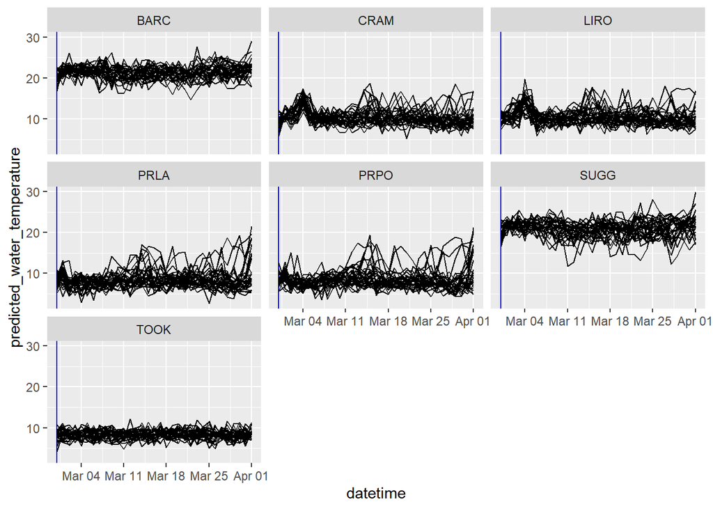

[figure not shown]

Remember to change the model_id when you make changes to the model structure!